# Drake_Zhou_Part_03_D_02

Drake Zhou

4/26/2022

# Overview & Initialization

## Package Import

```r
library(tidyverse)
library(caret)
library(coefplot)
library(rstanarm)
library(splines)
```

## Data Import

```r
df_all <- readr::read_csv("final_project_train.csv", col_names = TRUE)
# Input standarize
standard_df_all <- df_all %>%
  select(starts_with("x")) %>%
  # scale(center = TRUE, scale = TRUE) %>%
  # as.data.frame() %>%
  # tibble::as_tibble() %>%
  mutate(obs = factor(df_all$outcome, levels = c("event", "non_event")),
         region = df_all$region,
         customer = df_all$customer)

# Resampling
train_id <- sample(1:nrow(standard_df_all), size = floor(0.8 * nrow(standard_df_all)))
train_ready <- standard_df_all %>% slice(train_id)
test_ready <- standard_df_all %>% slice(-train_id)
```

# Model Training

You must train, evaluate, tune, and compare simple to complex models via resampling.• You may use either caret or tidymodels to handle the preprocessing, training, testing, and evaluation. You must decide the resampling scheme, what kind of preprocessing options you should consider.

## Training parameter

```r
my_ctrl <- trainControl(method = "repeatedcv",
                        number = 5,
                        repeats = 3,
                        summaryFunction = twoClassSummary,
                        classProbs = TRUE,
                        savePredictions = TRUE)

my_metric <- "ROC"
```

You must train and tune the following models: • Generalized linear models: • All categorical and continuous inputs - linear additive features • All pairwise interactions of continuous inputs, include additive categorical features • The 2 models selected from iiiA)

## Linear models

```r
set.seed(1024)
fit_roc_cat_lm_add <- train(obs ~ .,
                  data = standard_df_all,
                  method = "glm",
                  metric = my_metric,
                  preProcess = c("center", "scale"),
                  trControl = my_ctrl)

fit_roc_cat_lm_add
```

```
## Generalized Linear Model
##
## 677 samples
##  35 predictor
##   2 classes: 'event', 'non_event'
##
## Pre-processing: centered (43), scaled (43)
## Resampling: Cross-Validated (5 fold, repeated 3 times)
## Summary of sample sizes: 542, 541, 542, 542, 541, 542, ...
## Resampling results:
##
##   ROC        Sens       Spec
##   0.8318163  0.4071795  0.930303
```

```r
set.seed(1024)
fit_roc_cat_lm_pair <- train(obs ~ region + customer + (.)^2,
                  data = standard_df_all,
                  method = "glm",
                  metric = my_metric,
                  preProcess = c("center", "scale"),
                  trControl = my_ctrl)

fit_roc_cat_lm_pair
```

```
## Generalized Linear Model
##
## 677 samples
##  35 predictor
##   2 classes: 'event', 'non_event'
##
## Pre-processing: centered (917), scaled (917)
## Resampling: Cross-Validated (5 fold, repeated 3 times)
## Summary of sample sizes: 542, 541, 542, 542, 541, 542, ...
## Resampling results:
##
##   ROC        Sens       Spec
##   0.5194601  0.5299487  0.5084848
```

```r
set.seed(1024)
fit_roc_cat_lm_mod1 <- train(obs ~ region + customer,
                  data = standard_df_all,
                  method = "glm",
                  metric = my_metric,
                  preProcess = c("center", "scale"),
                  trControl = my_ctrl)

fit_roc_cat_lm_mod1
```

```
## Generalized Linear Model
##
## 677 samples
##   2 predictor
##   2 classes: 'event', 'non_event'
##
## Pre-processing: centered (10), scaled (10)
## Resampling: Cross-Validated (5 fold, repeated 3 times)
## Summary of sample sizes: 542, 541, 542, 542, 541, 542, ...
## Resampling results:
##
##   ROC        Sens  Spec
##   0.6056918  0     1
```

```r
set.seed(1024)
fit_roc_cat_lm_mod2 <- train(obs ~ .,
                  data = standard_df_all[c(-36, -35)],
                  method = "glm",
                  metric = my_metric,
                  preProcess = c("center", "scale"),
                  trControl = my_ctrl)

fit_roc_cat_lm_mod2
```

```
## Generalized Linear Model
##
## 677 samples
##  33 predictor
##   2 classes: 'event', 'non_event'
##
## Pre-processing: centered (33), scaled (33)
## Resampling: Cross-Validated (5 fold, repeated 3 times)
## Summary of sample sizes: 542, 541, 542, 542, 541, 542, ...
## Resampling results:
##
##   ROC        Sens       Spec
##   0.8192503  0.4019487  0.9381818
```

## Elastic Net models

• Regularized logistic regression with Elastic net • All pairwise interactions of continuous inputs, include additive categorical features • The more complex of the 2 models selected from iiA)

```r
set.seed(1024)
fit_roc_cat_enet_pair <- train(obs ~ region + customer + (.)^2,
                               data = standard_df_all,
                               method = "glmnet",
                               metric = my_metric,
                               preProcess = c("center", "scale"),
                               trControl = my_ctrl)

fit_roc_cat_enet_pair
```

```
## glmnet
##
## 677 samples
##  35 predictor
##   2 classes: 'event', 'non_event'
##
## Pre-processing: centered (917), scaled (917)
## Resampling: Cross-Validated (5 fold, repeated 3 times)
## Summary of sample sizes: 542, 541, 542, 542, 541, 542, ...
## Resampling results across tuning parameters:
##
##   alpha  lambda      ROC        Sens         Spec
##   0.10   0.01039198  0.8028960  0.386974359  0.9133333
##   0.10   0.03286232  0.8214956  0.349846154  0.9351515
##   0.10   0.10391977  0.8414704  0.247282051  0.9624242
##   0.55   0.01039198  0.8179618  0.336410256  0.9357576
##   0.55   0.03286232  0.8438070  0.233846154  0.9672727
##   0.55   0.10391977  0.8386424  0.065333333  0.9921212
##   1.00   0.01039198  0.8320149  0.307487179  0.9484848
##   1.00   0.03286232  0.8458061  0.181230769  0.9739394
##   1.00   0.10391977  0.8271632  0.007794872  1.0000000
##
## ROC was used to select the optimal model using the largest value.
## The final values used for the model were alpha = 1 and lambda = 0.03286232.
```

```r
formula_mod7 <- obs ~ poly(xb_01, 2)+poly(xb_02, 2)+ poly(xb_03,2)+poly(xn_01,2)+poly(xn_02,2)+poly(xn_03,2)+poly(xa_01,2)+poly(xa_02,2)+poly(xa_03,2)+poly(xb_04,2)+poly(xb_05,2)+poly(xb_06,2)+poly(xb_07,2)+poly(xb_08,2)+poly(xn_04,2)+poly(xn_05,2)+poly(xn_06,2)+poly(xn_07,2)+poly(xn_08,2)+poly(xa_04,2)+poly(xa_05,2)+poly(xa_06,2)+poly(xa_07,2)+poly(xa_08,2)+poly(xw_01,2)+poly(xw_02,2)+poly(xw_03,2)+poly(xs_01,2)+poly(xs_02,2)+poly(xs_03,2)+poly(xs_04,2)+poly(xs_05,2)+poly(xs_06,2)+region+customer

set.seed(1024)
fit_roc_cat_enet_mod7 <- train(formula_mod7,
                       data = standard_df_all,
                       method = "glmnet",
                       metric = my_metric,
                       preProcess = c("center", "scale"),
                       trControl = my_ctrl)

fit_roc_cat_enet_mod7
```

```
## glmnet
##
## 677 samples
##  35 predictor
##   2 classes: 'event', 'non_event'
##
## Pre-processing: centered (76), scaled (76)
## Resampling: Cross-Validated (5 fold, repeated 3 times)
## Summary of sample sizes: 542, 541, 542, 542, 541, 542, ...
## Resampling results across tuning parameters:
##
##   alpha  lambda        ROC        Sens       Spec
##   0.10   0.0003286232  0.7991991  0.4098462  0.8963636
##   0.10   0.0032862318  0.8208401  0.3861538  0.9315152
##   0.10   0.0328623182  0.8449995  0.2816410  0.9636364
##   0.55   0.0003286232  0.8001958  0.4098462  0.8963636
##   0.55   0.0032862318  0.8260494  0.3495385  0.9375758
##   0.55   0.0328623182  0.8465203  0.1972308  0.9690909
##   1.00   0.0003286232  0.8000448  0.4072821  0.8975758
##   1.00   0.0032862318  0.8279291  0.3310769  0.9430303
##   1.00   0.0328623182  0.8369725  0.1705641  0.9739394
##
## ROC was used to select the optimal model using the largest value.
## The final values used for the model were alpha = 0.55 and lambda = 0.03286232.
```

```r
formula_mod9 <- obs ~ ns(xb_01, 3)+ns(xb_03, 3)+ ns(xb_03,3)+ns(xn_01,3)+ns(xn_03,3)+ns(xn_03,3)+ns(xa_01,3)+ns(xa_03,3)+ns(xa_03,3)+ns(xb_04,3)+ns(xb_05,3)+ns(xb_06,3)+ns(xb_07,3)+ns(xb_08,3)+ns(xn_04,3)+ns(xn_05,3)+ns(xn_06,3)+ns(xn_07,3)+ns(xn_08,3)+ns(xa_04,3)+ns(xa_05,3)+ns(xa_06,3)+ns(xa_07,3)+ns(xa_08,3)+ns(xw_01,3)+ns(xw_03,3)+ns(xw_03,3)+ns(xs_01,3)+ns(xs_03,3)+ns(xs_03,3)+ns(xs_04,3)+ns(xs_05,3)+ns(xs_06,3)+region+customer

set.seed(1024)
fit_roc_cat_enet_mod9 <- train(formula_mod9,
                       data = standard_df_all,
                       method = "glmnet",
                       metric = my_metric,
                       preProcess = c("center", "scale"),
                       trControl = my_ctrl)

fit_roc_cat_enet_mod9
```

```
## glmnet
##
## 677 samples
##  30 predictor
##   2 classes: 'event', 'non_event'
##
## Pre-processing: centered (94), scaled (94)
## Resampling: Cross-Validated (5 fold, repeated 3 times)
## Summary of sample sizes: 542, 541, 542, 542, 541, 542, ...
## Resampling results across tuning parameters:
##
##   alpha  lambda        ROC        Sens       Spec
##   0.10   0.0003458016  0.8047795  0.4077949  0.8987879
##   0.10   0.0034580162  0.8185156  0.3606154  0.9206061
##   0.10   0.0345801621  0.8318536  0.2976410  0.9496970
##   0.55   0.0003458016  0.8035487  0.4025641  0.8969697
##   0.55   0.0034580162  0.8202005  0.3528205  0.9242424
##   0.55   0.0345801621  0.8390331  0.2210256  0.9636364
##   1.00   0.0003458016  0.8018107  0.4053333  0.8963636
##   1.00   0.0034580162  0.8201016  0.3448205  0.9278788
##   1.00   0.0345801621  0.8427361  0.1868718  0.9703030
##
## ROC was used to select the optimal model using the largest value.
## The final values used for the model were alpha = 1 and lambda = 0.03458016.
```

## Neural network

Fit the model as a warmup, then use parameters to further tune this model.

```r
set.seed(1024)

fit_roc_cat_nnet_warmup <- train(obs ~ .,
                    data = standard_df_all,
                    method = "nnet",
                    metric = my_metric,
                    preProcess = c("center", "scale"),
                    trControl = my_ctrl,
                    trace = FALSE)

fit_roc_cat_nnet_warmup
```

```
## Neural Network
##
## 677 samples
##  35 predictor
##   2 classes: 'event', 'non_event'
##
## Pre-processing: centered (43), scaled (43)
## Resampling: Cross-Validated (5 fold, repeated 3 times)
## Summary of sample sizes: 542, 541, 542, 542, 541, 542, ...
## Resampling results across tuning parameters:
##
##   size  decay  ROC        Sens       Spec
##   1     0e+00  0.7392270  0.4677949  0.8181818
##   1     1e-04  0.7567804  0.5649231  0.7806061
##   1     1e-01  0.8334490  0.5016410  0.8921212
##   3     0e+00  0.7727716  0.4803077  0.8721212
##   3     1e-04  0.7876802  0.5133333  0.8593939
##   3     1e-01  0.7906713  0.4626667  0.8745455
##   5     0e+00  0.7608811  0.4407179  0.8672727
##   5     1e-04  0.7910200  0.5041026  0.8715152
##   5     1e-01  0.7932476  0.4329231  0.8793939
##
## ROC was used to select the optimal model using the largest value.
## The final values used for the model were size = 1 and decay = 0.1.
```

Visualize the result and find tuning parameters

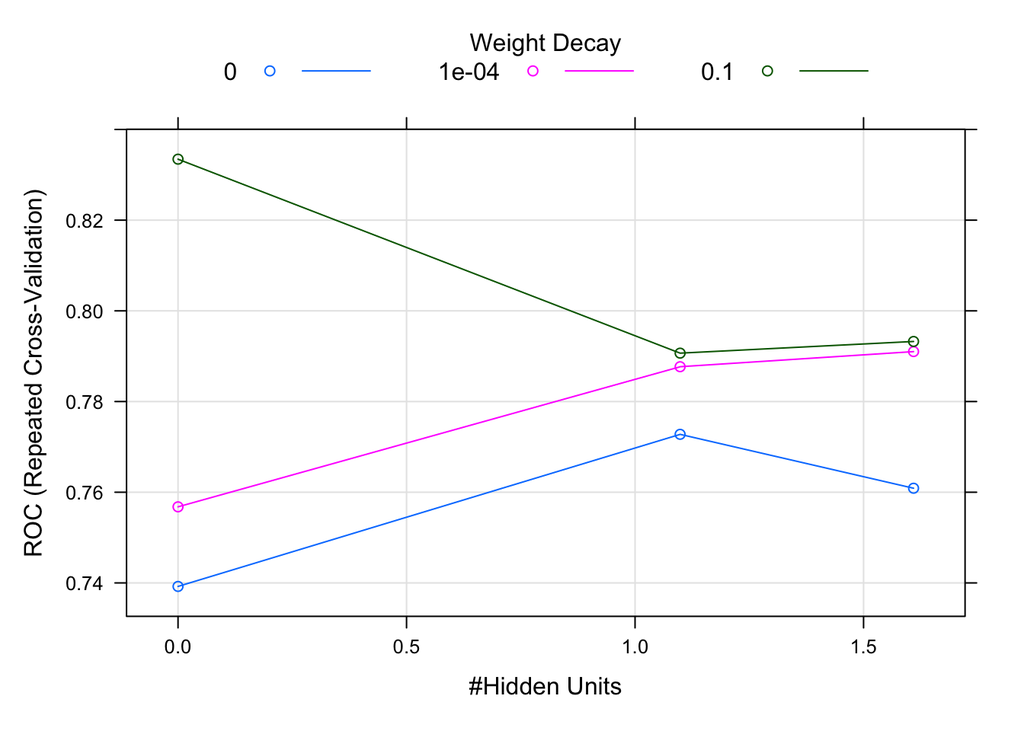

```r
plot(fit_roc_cat_nnet_warmup, xTrans = log)
```

```r
tune_grid_neural <- expand.grid(size = c(1:5, 10),
                                decay = c(0, 0.05, 0.1, 1, 2))

fit_roc_cat_nnet_tune <- train(obs ~ .,
                    data = standard_df_all,
                    method = "nnet",
                    metric = my_metric,
                    tuneGrid = tune_grid_neural,
                    preProcess = c("center", "scale"),
                    trControl = my_ctrl,
                    trace = FALSE)
```

Check the result

```r
fit_roc_cat_nnet_tune
```

```
## Neural Network
##
## 677 samples
##  35 predictor
##   2 classes: 'event', 'non_event'
##
## Pre-processing: centered (43), scaled (43)
## Resampling: Cross-Validated (5 fold, repeated 3 times)
## Summary of sample sizes: 542, 541, 542, 542, 541, 542, ...
## Resampling results across tuning parameters:
##
##   size  decay  ROC        Sens       Spec
##    1    0.00   0.7271860  0.5992821  0.7769697
##    1    0.05   0.8178853  0.5627692  0.8612121
##    1    0.10   0.8248662  0.4917949  0.8921212
```

[output cut: 30 more lines]

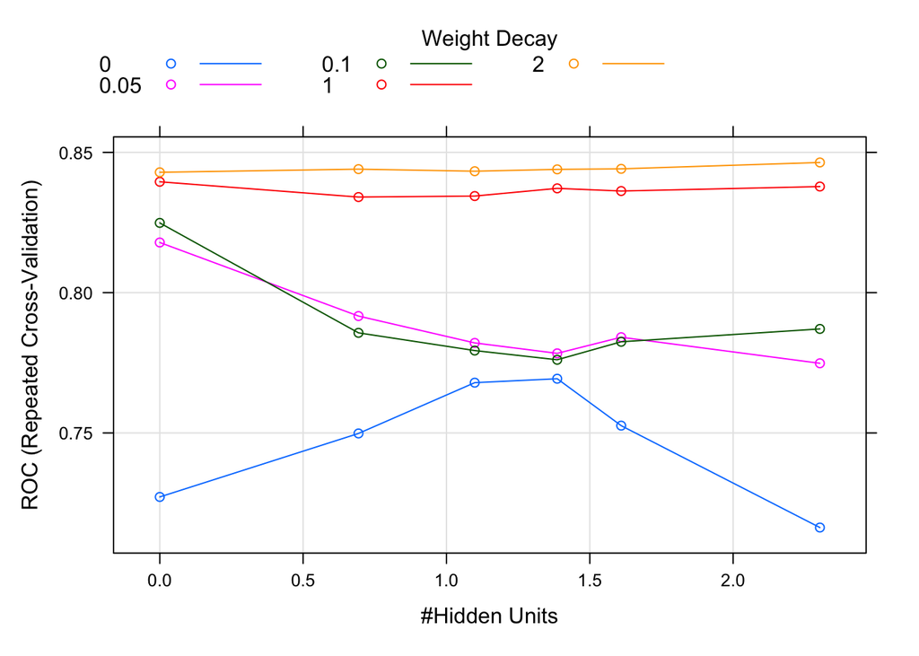

```r
plot(fit_roc_cat_nnet_tune, xTrans = log)
```

## Random forest

```r
set.seed(12341)
fit_roc_cat_rf_tune <- train(obs ~ .,
                     data = standard_df_all,
                     method = "rf",
                     metric = my_metric,
                     trControl = my_ctrl,
                     tuneGrid = expand.grid(mtry = seq(2, 8, by = 1)),
                     importance = TRUE)

fit_roc_cat_rf_tune
```

```
## Random Forest
##
## 677 samples
##  35 predictor
##   2 classes: 'event', 'non_event'
##
## No pre-processing
## Resampling: Cross-Validated (5 fold, repeated 3 times)
## Summary of sample sizes: 542, 542, 541, 542, 541, 541, ...
## Resampling results across tuning parameters:
##
##   mtry  ROC        Sens       Spec
##   2     0.8324503  0.2258462  0.9581818
##   3     0.8307543  0.2388718  0.9503030
##   4     0.8310769  0.2808205  0.9460606
##   5     0.8299790  0.2808205  0.9400000
##   6     0.8289627  0.2884103  0.9381818
##   7     0.8302918  0.2884103  0.9400000
##   8     0.8272751  0.2993846  0.9339394
##
## ROC was used to select the optimal model using the largest value.
## The final value used for the model was mtry = 2.
```

## Gradient boosted tree

```r
set.seed(12341)
fit_roc_cat_gbm_warmup <- train(obs ~ .,
                      data = standard_df_all,
                      method = "gbm",
                      metric = my_metric,
                      trControl = my_ctrl,
                      verbose = FALSE)

fit_roc_cat_gbm_warmup
```

```
## Stochastic Gradient Boosting
##
## 677 samples
##  35 predictor
##   2 classes: 'event', 'non_event'
##
## No pre-processing
## Resampling: Cross-Validated (5 fold, repeated 3 times)
## Summary of sample sizes: 542, 542, 541, 542, 541, 541, ...
## Resampling results across tuning parameters:
##
##   interaction.depth  n.trees  ROC        Sens       Spec
##   1                   50      0.8246872  0.2916923  0.9490909
##   1                  100      0.8270844  0.3335385  0.9400000
##   1                  150      0.8224597  0.3338462  0.9351515
##   2                   50      0.8229128  0.3096410  0.9315152
##   2                  100      0.8171002  0.3539487  0.9236364
##   2                  150      0.8130051  0.3651282  0.9212121
##   3                   50      0.8239413  0.3545641  0.9242424
##   3                  100      0.8120867  0.3701538  0.9109091
##   3                  150      0.8042023  0.3302564  0.9096970
##
## Tuning parameter 'shrinkage' was held constant at a value of 0.1
##
## Tuning parameter 'n.minobsinnode' was held constant at a value of 10
## ROC was used to select the optimal model using the largest value.
## The final values used for the model were n.trees = 100, interaction.depth =
##  1, shrinkage = 0.1 and n.minobsinnode = 10.
```

Visualize the result and finding best tuning parameters

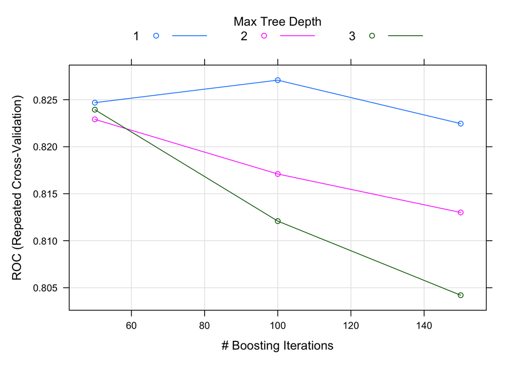

```r
plot(fit_roc_cat_gbm_warmup)
```

Tuning GBM model

```r
gbm_grid <- expand.grid(n.trees = c(100, 150, 300, 500, 750, 1000),
                        shrinkage = c(0.01, 0.1),
                        interaction.depth = fit_roc_cat_gbm_warmup$bestTune$interaction.depth,
                        n.minobsinnode = fit_roc_cat_gbm_warmup$bestTune$n.minobsinnode)

set.seed(12341)
fit_roc_cat_gbm_tune <- train(obs ~ .,
                      data = standard_df_all,
                      method = "gbm",
                      metric = my_metric,
                      tuneGrid = gbm_grid,
                      trControl = my_ctrl,
                      verbose=FALSE)
```

Check the result

```r
fit_roc_cat_gbm_tune
```

```
## Stochastic Gradient Boosting
##
## 677 samples
##  35 predictor
##   2 classes: 'event', 'non_event'
##
## No pre-processing
## Resampling: Cross-Validated (5 fold, repeated 3 times)
## Summary of sample sizes: 542, 542, 541, 542, 541, 541, ...
## Resampling results across tuning parameters:
##
##   shrinkage  n.trees  ROC        Sens        Spec
##   0.01        100     0.8212424  0.00000000  1.0000000
##   0.01        150     0.8254634  0.04235897  0.9872727
##   0.01        300     0.8259804  0.21600000  0.9569697
##   0.01        500     0.8275944  0.26051282  0.9484848
##   0.01        750     0.8289818  0.29979487  0.9436364
##   0.01       1000     0.8279357  0.30492308  0.9418182
##   0.10        100     0.8201193  0.34646154  0.9327273
##   0.10        150     0.8176364  0.32307692  0.9345455
##   0.10        300     0.8111487  0.34615385  0.9175758
##   0.10        500     0.8005417  0.35958974  0.9103030
##   0.10        750     0.7913044  0.36502564  0.9060606
##   0.10       1000     0.7879804  0.38851282  0.8975758
##
## Tuning parameter 'interaction.depth' was held constant at a value of 1
##
## Tuning parameter 'n.minobsinnode' was held constant at a value of 10
## ROC was used to select the optimal model using the largest value.
## The final values used for the model were n.trees = 750, interaction.depth =
##  1, shrinkage = 0.01 and n.minobsinnode = 10.
```

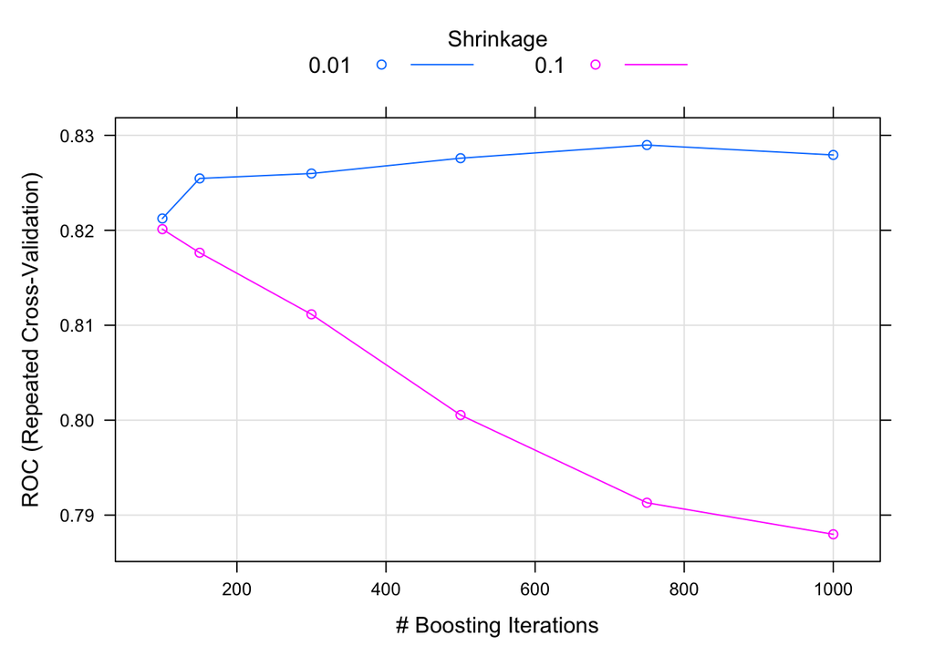

```r
plot(fit_roc_cat_gbm_tune)
```

## PLS

```r
pls_grid <- expand.grid(ncomp = 1:5)
set.seed(1024)
fit_roc_cat_cls_pls <- train(
  obs ~ .,
  data = standard_df_all,
  method = "pls",
  metric = my_metric,
  trControl = my_ctrl,
  tuneGrid = pls_grid,
  preProcess = c('center', 'scale')
)
```

## SVM

• 2 methods of your choice that we did not explicitly discuss in lecture

```r
set.seed(1024)
fit_roc_cat_svm_tune <- train(obs ~ .,
                 data = standard_df_all,
                 method = "svmRadial",
                 metric = my_metric,
                 preProcess = c("center", "scale"),
                 trControl = my_ctrl)

fit_roc_cat_svm_tune
```

```
## Support Vector Machines with Radial Basis Function Kernel
##
## 677 samples
##  35 predictor
##   2 classes: 'event', 'non_event'
##
## Pre-processing: centered (43), scaled (43)
## Resampling: Cross-Validated (5 fold, repeated 3 times)
## Summary of sample sizes: 542, 541, 542, 542, 541, 542, ...
## Resampling results across tuning parameters:
##
##   C     ROC        Sens       Spec
##   0.25  0.7953427  0.2393846  0.9563636
##   0.50  0.7951319  0.2365128  0.9563636
##   1.00  0.7971478  0.2367179  0.9600000
##
## Tuning parameter 'sigma' was held constant at a value of 0.0170321
## ROC was used to select the optimal model using the largest value.
## The final values used for the model were sigma = 0.0170321 and C = 1.
```

# Model Evaluation

•You must identify the best model.

## Comparasion

```r
my_performance <- resamples(list(LM_1 = fit_roc_cat_lm_add,
                                 #LM_2 = fit_roc_cat_lm_pair,
                                 LM_MOD1 = fit_roc_cat_lm_mod1,
                                 LM_MOD2 = fit_roc_cat_lm_mod2,
                                 ENET_PAIR = fit_roc_cat_enet_pair,
                                 ENET_MOD7 = fit_roc_cat_enet_mod7,
                                 ENET_MOD9 = fit_roc_cat_enet_mod9,
                                 GBM_W = fit_roc_cat_gbm_warmup,
                                 GBN_T = fit_roc_cat_gbm_tune,
                                 NNET_W = fit_roc_cat_nnet_warmup,
                                 NNET_T = fit_roc_cat_nnet_tune,
                                 RF = fit_roc_cat_rf_tune,
                                 SVM = fit_roc_cat_svm_tune,
                                 PLS = fit_roc_cat_cls_pls
                                 )
                            )
```

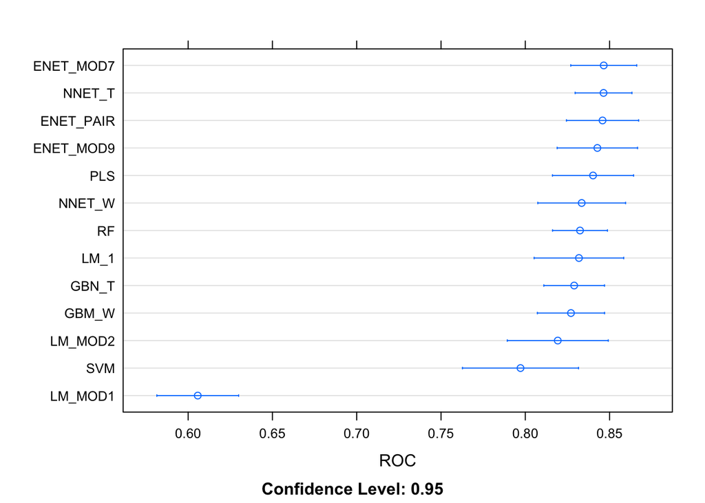

```r
dotplot(my_performance, metric = "ROC")
```

## Export model

```r
fit_roc_cat_lm_add %>% readr::write_rds('models/fit_roc_cat_lm_add.rds')
fit_roc_cat_lm_pair %>% readr::write_rds('models/fit_roc_cat_lm_pair.rds')
fit_roc_cat_lm_mod1 %>% readr::write_rds('models/fit_roc_cat_lm_mod1.rds')
fit_roc_cat_lm_mod2 %>% readr::write_rds('models/fit_roc_cat_lm_mod2.rds')
fit_roc_cat_enet_pair %>% readr::write_rds('models/fit_roc_cat_enet_pair.rds')
fit_roc_cat_enet_mod7 %>% readr::write_rds('models/fit_roc_cat_enet_mod7.rds')
fit_roc_cat_enet_mod9 %>% readr::write_rds('models/fit_roc_cat_enet_mod9.rds')
fit_roc_cat_gbm_warmup %>% readr::write_rds('models/fit_roc_cat_gbm_warmup.rds')
fit_roc_cat_gbm_tune %>% readr::write_rds('models/fit_roc_cat_gbm_tune.rds')
fit_roc_cat_nnet_warmup %>% readr::write_rds('models/fit_roc_cat_nnet_warmup.rds')
fit_roc_cat_nnet_tune %>% readr::write_rds('models/fit_roc_cat_nnet_tune.rds')
fit_roc_cat_rf_tune %>% readr::write_rds('models/fit_roc_cat_rf_tune.rds')
fit_roc_cat_svm_tune %>% readr::write_rds('models/fit_roc_cat_svm_tune.rds')
fit_roc_cat_cls_pls %>% readr::write_rds('models/fit_roc_cat_cls_pls.rds')
```